# Seleccion de variables

Sergio Nava

2023-04-24

## Máxima Verosimilitud

La función de verosimilitud (likelihood function) para Regresión Lineal Múltiple (RLM) se puede calcular utilizando la distribución normal multivariante.

Dada una matriz de diseño $X$ (que incluye la columna de unos correspondiente al término constante) y un vector de parámetros $\beta$, la función de verosimilitud se define como:
$$L(\beta|X,y)=(2\pi)^{-n/2}\cdot
det(\Sigma)^{-1/2}\cdot
exp(-\frac{1}{2}(y-X\beta)'\Sigma^{-1}(y-X\beta))$$
donde $y$ es el vector de respuestas, $n$ es el número de observaciones, $\Sigma$ es la matriz de covarianza de los errores aleatorios (asumidos como normales e independientes) y $\det()$ se refiere al determinante de la matriz.

En la práctica, la función de verosimilitud se maximiza para obtener los estimadores de máxima verosimilitud (MLE) de los parámetros $\beta$. Esto se puede hacer utilizando técnicas de optimización numérica, como el método de Newton-Raphson o el descenso de gradiente.

## AIC (Akaike Information Criterion)

El AIC (Akaike Information Criterion) es una medida de la calidad del ajuste de un modelo estadístico que penaliza los modelos más complejos. El AIC se define como:

$$AIC = 2k - 2ln(L),$$

donde $k$ es el número de parámetros del modelo y $L$ es la función de verosimilitud del modelo. El objetivo del AIC es encontrar el modelo que tenga la menor distancia de información de Akaike (AIC) y, por lo tanto, se ajuste mejor a los datos observados.

Un ejemplo en el que se puede utilizar el AIC es en la selección de modelos para un conjunto de datos. Supongamos que tenemos un conjunto de datos que queremos ajustar con diferentes modelos de regresión lineal múltiple. Podemos utilizar el AIC para seleccionar el modelo que tenga el menor AIC, lo que indica que ese modelo se ajusta mejor a los datos.

A continuación, presento un ejemplo de cómo utilizar el AIC en R para seleccionar el mejor modelo de regresión lineal múltiple para un conjunto de datos. En este ejemplo, utilizaremos el conjunto de datos mtcars que viene precargado en R:

```r
# Cargamos el conjunto de datos mtcars
data(mtcars)

# Dividimos el conjunto de datos en entrenamiento y prueba
set.seed(123)
ind <- sample(2, nrow(mtcars), replace=TRUE, prob=c(0.7, 0.3))
train_data <- mtcars[ind == 1, ]
test_data <- mtcars[ind == 2, ]

# Ajustamos diferentes modelos de regresión lineal múltiple con diferentes combinaciones de características
model1 <- lm(mpg ~ wt + disp + hp, data=train_data)
model2 <- lm(mpg ~ wt + disp, data=train_data)
model3 <- lm(mpg ~ wt + hp, data=train_data)

# Calculamos el AIC de cada modelo
(AIC1 <- AIC(model1))
```

```
## [1] 104.0171
```

```r
(AIC2 <- AIC(model2))
```

```
## [1] 105.2331
```

```r
(AIC3 <- AIC(model3))
```

```
## [1] 102.1252
```

```r
# Seleccionamos el modelo con el menor AIC
if(AIC1 < AIC2 & AIC1 < AIC3) {
  model_best <- model1
} else if(AIC2 < AIC1 & AIC2 < AIC3) {
  model_best <- model2
} else {
  model_best <- model3
}

# Evaluamos el desempeño del modelo seleccionado utilizando el conjunto de prueba
pred_best <- predict(model_best, newdata=test_data)
rmse_best <- sqrt(mean((test_data$mpg - pred_best)^2))
rmse_best
```

```
## [1] 2.39542
```

## Selección de variables (características)

Primero, cargamos el conjunto de datos `mtcars` y lo dividimos en un conjunto de entrenamiento y un conjunto de prueba:

```r
# Cargamos el conjunto de datos mtcars
data(mtcars)
# Dividimos el conjunto de datos en entrenamiento y prueba
set.seed(123)
ind <- sample(2, nrow(mtcars), replace=TRUE, prob=c(0.7, 0.3))
train_data <- mtcars[ind == 1, ]
test_data <- mtcars[ind == 2, ]
```

Luego, ajustamos un modelo de regresión lineal múltiple utilizando todas las características disponibles y evaluamos su desempeño utilizando el conjunto de prueba:

```r
# Ajustamos un modelo de regresión lineal múltiple utilizando todas las características
model_full <- lm(mpg ~ ., data=train_data)
# Evaluamos el desempeño del modelo utilizando el conjunto de prueba
pred_full <- predict(model_full, newdata=test_data)
rmse_full <- sqrt(mean((test_data$mpg - pred_full)^2))
rmse_full
```

```
## [1] 2.983752
```

A continuación, realizamos la selección de características utilizando el método de eliminación hacia atrás:

```r
# Ajustamos un modelo de regresión lineal múltiple utilizando todas las características
model_full <- lm(mpg ~ ., data=train_data)

# Realizamos la eliminación hacia atrás
model_backward <- step(model_full, direction="backward")
```

```
## Start:  AIC=51.45
## mpg ~ cyl + disp + hp + drat + wt + qsec + vs + am + gear + carb
##
##        Df Sum of Sq    RSS    AIC
## - hp    1    0.1521 87.354 49.485
## - disp  1    0.2621 87.464 49.510
## - vs    1    0.6177 87.819 49.591
## - am    1    0.6198 87.821 49.591
## - qsec  1    1.1594 88.361 49.714
## - gear  1    1.8362 89.038 49.867
## - wt    1    2.0562 89.258 49.916
## - carb  1    3.3613 90.563 50.206
## - drat  1    5.8919 93.093 50.757
## - cyl   1    7.2495 94.451 51.047
## <none>              87.201 51.450
##
## Step:  AIC=49.48
## mpg ~ cyl + disp + drat + wt + qsec + vs + am + gear + carb
##
##        Df Sum of Sq    RSS    AIC
## - vs    1    0.5167 87.870 47.603
## - am    1    0.6085 87.962 47.623
## - disp  1    0.6501 88.004 47.633
## - qsec  1    1.1495 88.503 47.746
## - wt    1    1.9844 89.338 47.934
## - gear  1    2.8923 90.246 48.136
## - carb  1    4.3661 91.720 48.460
## - drat  1    6.2059 93.559 48.857
## <none>              87.354 49.485
## - cyl   1    9.5933 96.947 49.569
##
## Step:  AIC=47.6
## mpg ~ cyl + disp + drat + wt + qsec + am + gear + carb
##
##        Df Sum of Sq    RSS    AIC
## - am    1    0.4974 88.368 45.716
## - disp  1    0.6004 88.471 45.739
## - qsec  1    0.8216 88.692 45.789
## - wt    1    2.3406 90.211 46.128
## - gear  1    2.8351 90.705 46.238
```

[output cut: 52 more lines]

```
## mpg ~ cyl + wt + carb
##
##        Df Sum of Sq     RSS    AIC
## - carb  1     5.872 104.387 39.047
## <none>               98.515 39.890
## - wt    1    43.475 141.990 45.200
## - cyl   1    60.588 159.103 47.476
##
## Step:  AIC=39.05
## mpg ~ cyl + wt
##
##        Df Sum of Sq    RSS    AIC
## <none>              104.39 39.047
## - wt    1    45.010 149.40 44.217
## - cyl   1    75.074 179.46 47.885
```

```r
# Evaluamos el desempeño del modelo utilizando el conjunto de prueba
pred_backward <- predict(model_backward, newdata=test_data)
rmse_backward <- sqrt(mean((test_data$mpg - pred_backward)^2))
rmse_backward
```

```
## [1] 2.797792
```

Finalmente, realizamos la selección de características utilizando el método de selección hacia adelante:

```r
# Ajustamos un modelo de regresión lineal múltiple utilizando la característica más importante
model_forward <- lm(mpg ~ 1, data=train_data)

# Realizamos la selección hacia adelante
model_forward <- step(model_forward, scope=formula(model_full), direction="forward")
```

```
## Start:  AIC=72.65
## mpg ~ 1
##
##        Df Sum of Sq    RSS    AIC
## + cyl   1    534.79 149.40 44.217
## + wt    1    504.73 179.46 47.885
## + disp  1    499.20 184.99 48.491
## + hp    1    428.98 255.21 54.927
## + drat  1    361.65 322.54 59.610
## + am    1    329.68 354.51 61.500
## + vs    1    304.47 379.72 62.874
## + gear  1    244.72 439.47 65.797
## + carb  1    157.19 527.00 69.429
## <none>              684.19 72.650
## + qsec  1     51.30 632.89 73.091
##
## Step:  AIC=44.22
## mpg ~ cyl
##
##        Df Sum of Sq    RSS    AIC
## + wt    1    45.010 104.39 39.047
## + am    1    15.739 133.66 43.991
## <none>              149.40 44.217
## + disp  1    14.151 135.25 44.227
## + qsec  1    13.638 135.76 44.303
## + drat  1    11.144 138.25 44.667
## + carb  1     7.407 141.99 45.200
## + hp    1     5.347 144.05 45.488
## + gear  1     0.839 148.56 46.105
## + vs    1     0.297 149.10 46.178
##
## Step:  AIC=39.05
## mpg ~ cyl + wt
##
##        Df Sum of Sq     RSS    AIC
## <none>              104.387 39.047
## + carb  1    5.8715  98.515 39.890
## + gear  1    4.0702 100.317 40.252
## + hp    1    3.1555 101.231 40.434
## + drat  1    1.2659 103.121 40.803
## + vs    1    0.7941 103.593 40.895
## + disp  1    0.4419 103.945 40.963
## + qsec  1    0.4135 103.973 40.968
## + am    1    0.0235 104.363 41.043
```

```r
# Evaluamos el desempeño del modelo utilizando el conjunto de prueba
pred_forward <- predict(model_forward, newdata=test_data)
rmse_forward <- sqrt(mean((test_data$mpg - pred_forward)^2))
rmse_forward
```

```
## [1] 2.797792
```

Este es un ejemplo básico de cómo utilizar los métodos de selección de características backward elimination y forward selection para regresión lineal múltiple en R utilizando el conjunto de datos mtcars. Por supuesto, los resultados pueden variar dependiendo del conjunto de datos y del problema que se esté abordando.

## Ejercicio (Boston)

```r
data(Boston,package = "MASS")
```

| Variable predictora | Descripción |
| --- | --- |
| crim | Tasa de criminalidad per cápita por zona |
| zn | Proporción de terrenos residenciales en zonas de |
|  | más de 25,000 pies cuadrados por zona |
| indus | Proporción de acres comerciales no minoristas |
|  | por zona |
| chas | Variable ficticia del río Charles (= 1 si la zona |
|  | limita con el río; 0 en caso contrario) |
| nox | Concentración de óxidos nítricos (partes por 10 |
|  | millones) |
| rm | Número medio de habitaciones por vivienda |
| age | Proporción de unidades ocupadas por sus |
|  | propietarios construidas antes de 1940 |
| dis | Distancias ponderadas a cinco centros de empleo |
| rad | Índice de accesibilidad a carreteras radiales |
| tax | Tasa de impuesto a la propiedad por valor en $ |
| ptratio | Proporción alumno-profesor por zona |
| black | Proporción de negros por zona |
| lstat | Porcentaje de la población de bajo estatus social |
|  | por zona |
| medv | Valor mediano de las viviendas ocupadas por sus |
|  | propietarios en $1,000s |

```r
# Cargamos el conjunto de datos mtcars

# Dividimos el conjunto de datos en entrenamiento y prueba
set.seed(1233)
ind <- sample(2, nrow(Boston), replace=TRUE, prob=c(0.7, 0.3))
train_data <- Boston[ind == 1, ]
test_data <- Boston[ind == 2, ]
```

```r
# Ajustamos un modelo de regresión lineal múltiple utilizando todas las características
model_full <- lm(medv ~ ., data=train_data)
# Evaluamos el desempeño del modelo utilizando el conjunto de prueba
pred_full <- predict(model_full, newdata=test_data)
rmse_full <- sqrt(mean((test_data$medv - pred_full)^2))
rmse_full
```

```
## [1] 4.65262
```

```r
# Ajustamos un modelo de regresión lineal múltiple utilizando todas las características
model_full <- lm(medv ~ ., data=train_data)

# Realizamos la eliminación hacia atrás
model_backward <- step(model_full, direction="backward")
```

```
## Start:  AIC=1180.7
## medv ~ crim + zn + indus + chas + nox + rm + age + dis + rad +
##     tax + ptratio + black + lstat
##
##           Df Sum of Sq     RSS    AIC
## - age      1      3.35  8249.9 1178.8
## - indus    1     16.08  8262.6 1179.4
## <none>                  8246.5 1180.7
## - zn       1    137.98  8384.5 1184.9
## - black    1    155.07  8401.6 1185.6
## - crim     1    169.05  8415.6 1186.2
## - chas     1    191.55  8438.1 1187.2
## - tax      1    232.72  8479.2 1189.0
## - rad      1    392.22  8638.7 1196.0
## - nox      1    395.56  8642.1 1196.1
## - dis      1    762.24  9008.8 1211.6
## - ptratio  1    935.44  9181.9 1218.7
## - rm       1   1550.20  9796.7 1242.8
## - lstat    1   1795.29 10041.8 1252.0
##
## Step:  AIC=1178.85
## medv ~ crim + zn + indus + chas + nox + rm + dis + rad + tax +
##     ptratio + black + lstat
##
##           Df Sum of Sq     RSS    AIC
## - indus    1     16.48  8266.3 1177.6
## <none>                  8249.9 1178.8
## - zn       1    134.64  8384.5 1182.9
## - black    1    157.66  8407.5 1183.9
## - crim     1    168.12  8418.0 1184.3
## - chas     1    194.94  8444.8 1185.5
## - tax      1    231.07  8480.9 1187.1
## - rad      1    388.94  8638.8 1194.0
## - nox      1    400.46  8650.3 1194.5
## - dis      1    852.55  9102.4 1213.4
## - ptratio  1    932.09  9181.9 1216.7
## - rm       1   1657.71  9907.6 1245.0
## - lstat    1   1988.38 10238.2 1257.2
##
## Step:  AIC=1177.59
## medv ~ crim + zn + chas + nox + rm + dis + rad + tax + ptratio +
##     black + lstat
##
##           Df Sum of Sq     RSS    AIC
## <none>                  8266.3 1177.6
## - zn       1    127.34  8393.7 1181.3
## - black    1    154.67  8421.0 1182.5
## - crim     1    172.02  8438.4 1183.2
## - chas     1    208.22  8474.6 1184.8
## - tax      1    217.98  8484.3 1185.3
## - rad      1    372.95  8639.3 1192.0
## - nox      1    386.33  8652.7 1192.6
## - ptratio  1    915.78  9182.1 1214.7
## - dis      1    966.54  9232.9 1216.7
## - rm       1   1641.24  9907.6 1243.0
## - lstat    1   1972.02 10238.4 1255.2
```

```r
# Evaluamos el desempeño del modelo utilizando el conjunto de prueba
pred_backward <- predict(model_backward, newdata=test_data)
rmse_backward <- sqrt(mean((test_data$medv - pred_backward)^2))
rmse_backward
```

```
## [1] 4.630451
```

```r
# Ajustamos un modelo de regresión lineal múltiple utilizando la característica más importante
model_forward <- lm(medv ~ 1, data=train_data)

# Realizamos la selección hacia adelante
model_forward <- step(model_forward, scope=formula(model_full), direction="forward")
```

```
## Start:  AIC=1667.2
## medv ~ 1
##
##           Df Sum of Sq   RSS    AIC
## + lstat    1   17902.6 14801 1374.3
## + rm       1   16412.2 16291 1410.0
## + ptratio  1    8992.0 23711 1549.6
## + tax      1    6814.9 25888 1582.3
## + indus    1    6805.6 25898 1582.4
## + nox      1    6004.8 26698 1593.7
## + crim     1    5096.2 27607 1606.2
## + rad      1    4779.8 27923 1610.4
## + age      1    4546.4 28157 1613.5
## + zn       1    4312.4 28391 1616.6
## + black    1    3353.7 29349 1629.0
## + dis      1    1915.4 30788 1646.7
## + chas     1    1214.6 31489 1655.1
## <none>                 32703 1667.2
##
## Step:  AIC=1374.27
## medv ~ lstat
##
##           Df Sum of Sq   RSS    AIC
## + rm       1    3370.3 11430 1280.2
## + ptratio  1    2105.9 12695 1319.2
## + chas     1     789.8 14011 1355.9
## + dis      1     574.0 14227 1361.6
## + age      1     303.0 14498 1368.6
## + tax      1     232.0 14569 1370.4
## + crim     1     166.6 14634 1372.1
## + black    1      99.0 14702 1373.8
## <none>                 14801 1374.3
## + zn       1      48.8 14752 1375.0
## + rad      1      30.0 14770 1375.5
## + indus    1      18.9 14782 1375.8
## + nox      1       5.2 14795 1376.1
##
## Step:  AIC=1280.15
## medv ~ lstat + rm
##
```

[output cut: 109 more lines]

```
##
##         Df Sum of Sq    RSS    AIC
## + zn     1   127.339 8266.3 1177.6
## <none>               8393.7 1181.3
## + indus  1     9.180 8384.5 1182.9
## + age    1     0.019 8393.7 1183.3
##
## Step:  AIC=1177.59
## medv ~ lstat + rm + ptratio + dis + nox + chas + black + rad +
##     tax + crim + zn
##
##         Df Sum of Sq    RSS    AIC
## <none>               8266.3 1177.6
## + indus  1   16.4777 8249.9 1178.8
## + age    1    3.7417 8262.6 1179.4
```

```r
# Evaluamos el desempeño del modelo utilizando el conjunto de prueba
pred_forward <- predict(model_forward, newdata=test_data)
rmse_forward <- sqrt(mean((test_data$medv - pred_forward)^2))
rmse_forward
```

```
## [1] 4.630451
```

```r
# Ajustamos un modelo de regresión lineal múltiple utilizando la característica más importante
model_both <- lm(medv ~ 1, data=train_data)

# Realizamos la selección hacia adelante
model_both <- step(model_both, scope=formula(model_full), direction="both")
```

```
## Start:  AIC=1667.2
## medv ~ 1
##
##           Df Sum of Sq   RSS    AIC
## + lstat    1   17902.6 14801 1374.3
## + rm       1   16412.2 16291 1410.0
## + ptratio  1    8992.0 23711 1549.6
## + tax      1    6814.9 25888 1582.3
## + indus    1    6805.6 25898 1582.4
## + nox      1    6004.8 26698 1593.7
## + crim     1    5096.2 27607 1606.2
## + rad      1    4779.8 27923 1610.4
## + age      1    4546.4 28157 1613.5
## + zn       1    4312.4 28391 1616.6
## + black    1    3353.7 29349 1629.0
## + dis      1    1915.4 30788 1646.7
## + chas     1    1214.6 31489 1655.1
## <none>                 32703 1667.2
##
## Step:  AIC=1374.27
## medv ~ lstat
##
##           Df Sum of Sq   RSS    AIC
## + rm       1    3370.3 11430 1280.2
## + ptratio  1    2105.9 12695 1319.2
## + chas     1     789.8 14011 1355.9
## + dis      1     574.0 14227 1361.6
## + age      1     303.0 14498 1368.6
## + tax      1     232.0 14569 1370.4
## + crim     1     166.6 14634 1372.1
## + black    1      99.0 14702 1373.8
## <none>                 14801 1374.3
## + zn       1      48.8 14752 1375.0
## + rad      1      30.0 14771 1375.5
## + indus    1      18.9 14782 1375.8
## + nox      1       5.2 14795 1376.1
## - lstat    1   17902.6 32703 1667.2
##
## Step:  AIC=1280.15
## medv ~ lstat + rm
```

[output cut: 175 more lines]

```
##           Df Sum of Sq     RSS    AIC
## <none>                  8266.3 1177.6
## + indus    1     16.48  8249.9 1178.8
## + age      1      3.74  8262.6 1179.4
## - zn       1    127.34  8393.7 1181.3
## - black    1    154.67  8421.0 1182.5
## - crim     1    172.02  8438.4 1183.2
## - chas     1    208.22  8474.6 1184.8
## - tax      1    217.98  8484.3 1185.3
## - rad      1    372.95  8639.3 1192.0
## - nox      1    386.33  8652.7 1192.6
## - ptratio  1    915.78  9182.1 1214.7
## - dis      1    966.54  9232.9 1216.7
## - rm       1   1641.24  9907.6 1243.0
## - lstat    1   1972.02 10238.4 1255.2
```

```r
# Evaluamos el desempeño del modelo utilizando el conjunto de prueba
pred_both <- predict(model_both, newdata=test_data)
rmse_both <- sqrt(mean((test_data$medv - pred_both)^2))
rmse_both
```

```
## [1] 4.630451
```

```r
summary(model_backward)
```

```
##
## Call:
## lm(formula = medv ~ crim + zn + chas + nox + rm + dis + rad +
##     tax + ptratio + black + lstat, data = train_data)
##
## Residuals:
##      Min       1Q   Median       3Q      Max
## -16.7806  -2.8043  -0.4394   1.8151  26.7545
##
## Coefficients:
##               Estimate Std. Error t value Pr(>|t|)
## (Intercept)  34.679514   6.087923   5.696 2.55e-08 ***
## crim         -0.114941   0.041994  -2.737  0.00651 **
## zn            0.036962   0.015696   2.355  0.01906 *
## chas          3.080236   1.022881   3.011  0.00278 **
## nox         -17.357655   4.231733  -4.102 5.07e-05 ***
## rm            4.133072   0.488869   8.454 7.08e-16 ***
## dis          -1.403884   0.216384  -6.488 2.88e-10 ***
## rad           0.301971   0.074928   4.030 6.80e-05 ***
## tax          -0.012075   0.003919  -3.081  0.00222 **
## ptratio      -0.950030   0.150434  -6.315 7.95e-10 ***
## black         0.008288   0.003193   2.595  0.00983 **
## lstat        -0.526367   0.056799  -9.267  < 2e-16 ***
## ---
## Signif. codes:  0 '***' 0.001 '**' 0.01 '*' 0.05 '.' 0.1 ' ' 1
##
## Residual standard error: 4.792 on 360 degrees of freedom
## Multiple R-squared:  0.7472, Adjusted R-squared:  0.7395
## F-statistic: 96.75 on 11 and 360 DF,  p-value: < 2.2e-16
```

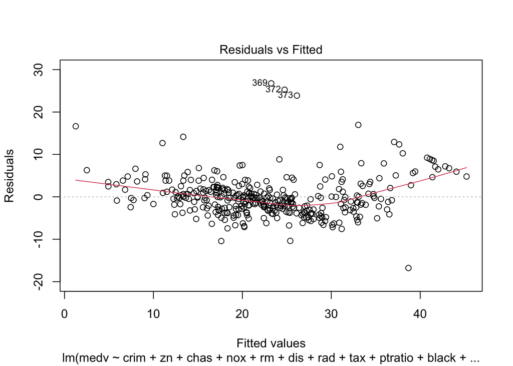

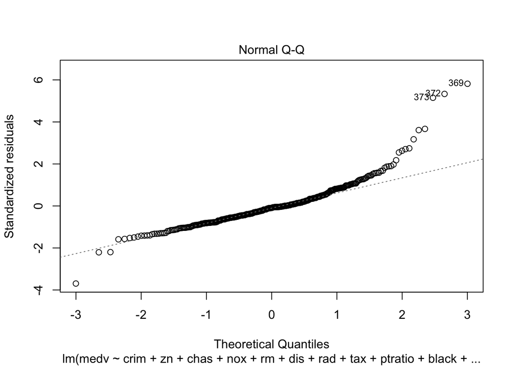

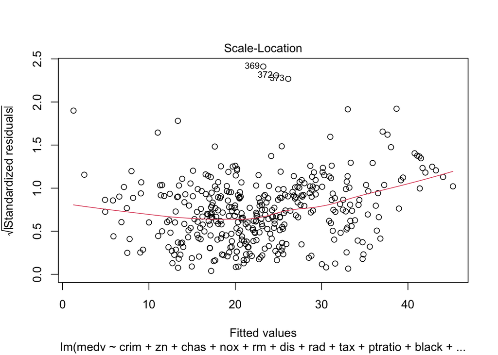

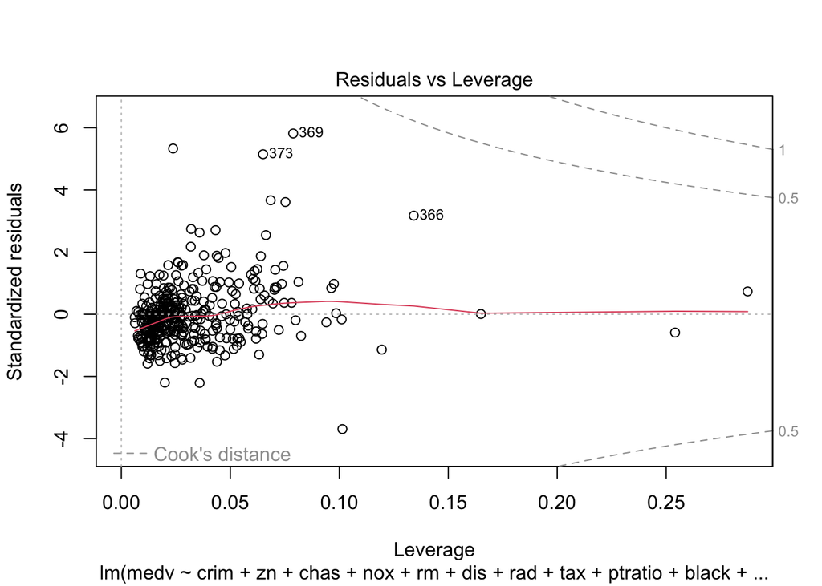

```r
plot(model_backward)
```

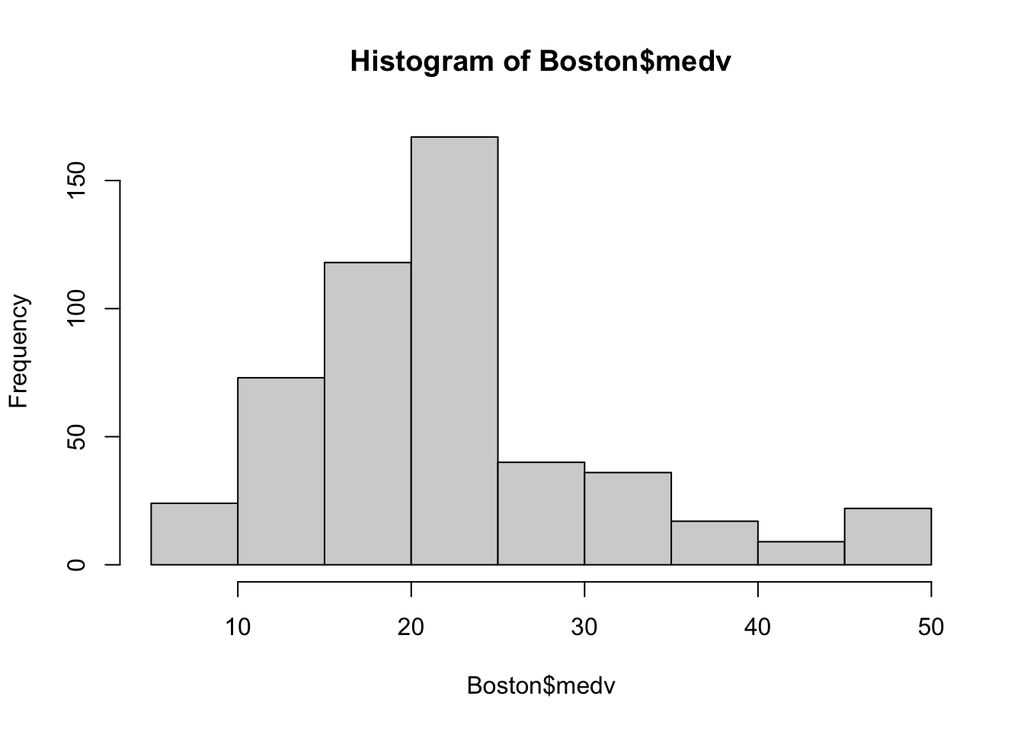

```r
hist(Boston$medv)
```